# Exploring the BRFSS data

George Liu

## Overview

In this project, we conduct Exploratory Data Analysis (EDA) using the The Behavioral Risk Factor Surveillance System (BRFSS) 2013 dataset. According to the [official site](http://www.cdc.gov/brfss/data_documentation/index.htm), “BRFSS is an ongoing surveillance system designed to measure behavioral risk factors for the non-institutionalized adult population (18 years of age and older) residing in the US. The BRFSS objective is to collect uniform, state-specific data on preventive health practices and risk behaviors that are linked to chronic diseases, injuries, and preventable infectious diseases that affect the adult population.”

## Setup

### Load packages

```r
library(ggplot2)
library(dplyr)
```

### Load data

```r
load("brfss2013.RData")
```

## Part 1: Data

According to [BRFSS](http://www.cdc.gov/brfss/annual_data/2013/pdf/Overview_2013.pdf), the data was collected using disproportionate stratified sample and simple random sample methods. Since they are all random sampling techniques, any analysis result we get from this sample can be generalized to the general population, in this case, the United States aldult population. On the other hand, since random assignment is not involved, we cannot draw any causal conclusions.

## Part 2: Research questions

We have the following three questions to investigate using the data. The first two questions are interesting as they can be informative for people who care about their health. The third question is useful to government agencies or non profit organizations as they can use it to target certain groups for education and prevention purposes.

**Research quesion 1:** Is amount of sleep correlated with health? More specifically, do people who sleep less have a higher probability of being diagnosed for heart attack?

**Research quesion 2:** Is there relationship between smoking, drikining and health? Do people who smoke/drink generally have worse health?

**Research quesion 3:** Are seatbelt usage rates connected with education? Do people with more education tend to use seatbelt more?

## Part 3: Exploratory data analysis

**Research quesion 1:**

Let’s start by examining the relationship between health and sleep time:

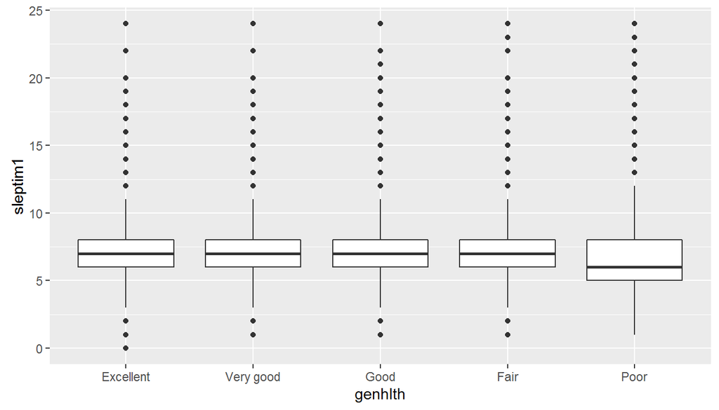

```r
sleep_time <- brfss2013 %>%
  select(genhlth, sleptim1) %>%
  filter(!is.na(genhlth) & !is.na(sleptim1))

ggplot(data=sleep_time, aes(x=genhlth, y=sleptim1)) +
  geom_boxplot()
```

There seems to be a trend in sleep time across different health groups. In particular the “Poor” health group has clearly lower median sleep time than other groups. Next, we calculate the mean sleep time for different groups.

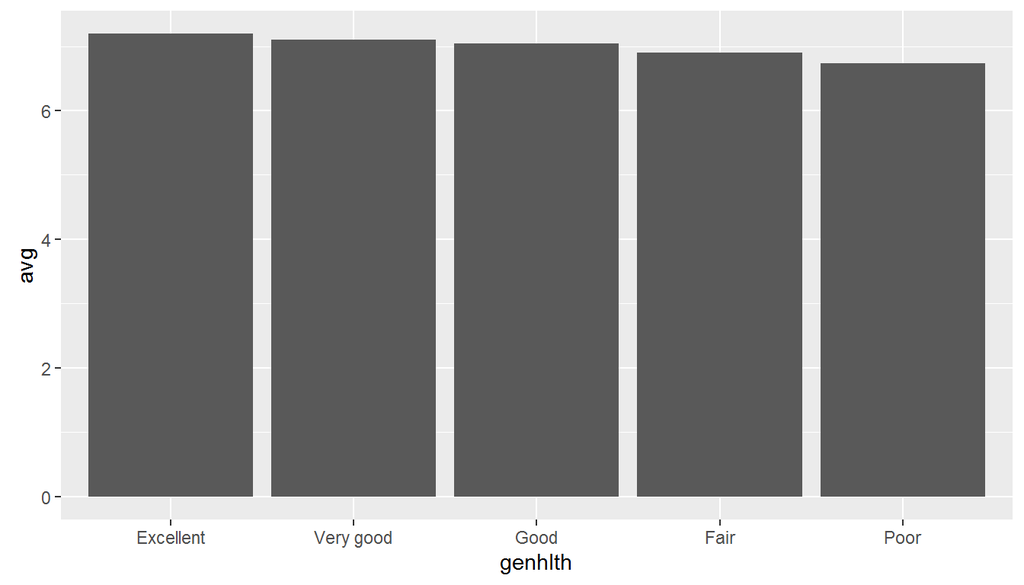

```r
sleep_avg <- sleep_time %>%
  group_by(genhlth) %>%
  summarise(avg=mean(sleptim1))

ggplot(data=sleep_avg, aes(x=genhlth, y=avg)) +
  geom_bar(stat = "identity")
```

So, it’s clear the average sleep time decreases from “Excellent” to “Poor” health group. Let’s also check the relationship between sleep and heart attack diagnosis.

```r
# Create a new variable indicating whether a subject has enough sleep or not
brfss2013 <- brfss2013 %>%
  mutate(enough_sleep=ifelse(sleptim1>=7, 'yes', 'no'))

brfss2013 %>%
  select(enough_sleep, cvdinfr4) %>%
  filter(!is.na(enough_sleep) & !is.na(cvdinfr4)) %>%
  group_by(enough_sleep, cvdinfr4) %>%
  summarize(count=n()) %>%
  mutate(percentage=count/sum(count))
```

```
## Source: local data frame [4 x 4]
## Groups: enough_sleep [2]
##
##   enough_sleep cvdinfr4  count percentage
##          <chr>   <fctr>  <int>      <dbl>
## 1           no      Yes  10573 0.06703397
## 2           no       No 147153 0.93296603
## 3          yes      Yes  17925 0.05527954
## 4          yes       No 306336 0.94472046
```

We can see that the percentage of heart attack is higher in the not enough sleep group. Therefore, there is a correlation between health and sleep time - with better health corresponding to more sleep.

**Research quesion 2:**

We now look at the relationship between smoking and health by checking out the distribution of health statuses in both smoking and non-smoking groups.

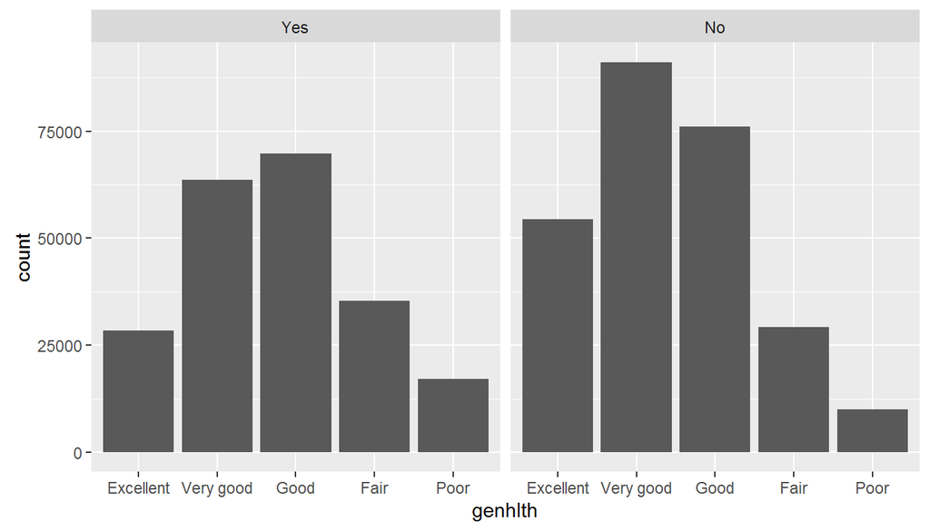

```r
smoke <- brfss2013 %>%
  select(smoke100, genhlth) %>%
  filter(!is.na(smoke100) & !is.na(genhlth)) %>%
  group_by(smoke100, genhlth) %>%
  arrange(smoke100, genhlth)

ggplot(data=smoke, aes(x=genhlth)) +
  geom_bar() +
  facet_wrap(~smoke100)
```

So the visualization indicates that for the non-smoking group, the proportion of good to excellent health people is significantly higher than that of the smoking group. Let’s quantify this using summary stats:

```r
smoke %>%
  summarise(count=n()) %>%
  mutate(proportion=count/sum(count))
```

```
## Source: local data frame [10 x 4]
## Groups: smoke100 [2]
##
##    smoke100   genhlth count proportion
##      <fctr>    <fctr> <int>      <dbl>
## 1       Yes Excellent 28342 0.13226311
## 2       Yes Very good 63642 0.29699699
## 3       Yes      Good 69765 0.32557109
## 4       Yes      Fair 35414 0.16526588
## 5       Yes      Poor 17122 0.07990293
## 6        No Excellent 54392 0.20863668
## 7        No Very good 91157 0.34965976
## 8        No      Good 75995 0.29150141
## 9        No      Fair 29195 0.11198610
## 10       No      Poor  9963 0.03821605
```

Next, let’s check the relationship between drinking, smoking and health. We’ll do this by adding a new variable drink_smoke - “yes” whenever the subject both drink and smoke. Also, we’ll split health into two groups: good or not.

```r
brfss2013 %>%
  mutate(drink_smoke = ifelse(smoke100=='Yes' & alcday5>0, 'yes', 'no')) %>%
  mutate(healthy = ifelse(genhlth== c('Fair', 'Poor'), 'bad', 'yes')) %>%
  group_by(drink_smoke, healthy) %>%
  summarise(count=n()) %>%
  mutate(proportion=count/sum(count))
```

```
## Source: local data frame [9 x 4]
## Groups: drink_smoke [3]
##
##   drink_smoke healthy  count  proportion
##         <chr>   <chr>  <int>       <dbl>
## 1          no     bad  36343 0.101162127
## 2          no     yes 321432 0.894718236
## 3          no      NA   1480 0.004119636
## 4         yes     bad   9325 0.080991879
## 5         yes     yes 105431 0.915716333
## 6         yes      NA    379 0.003291788
## 7          NA     bad   1797 0.103364970
## 8          NA     yes  15462 0.889387403
## 9          NA      NA    126 0.007247627
```

**Research quesion 3:**

We start investigating question 3 by converting the levels of the factor variable to shorter texts for better disply in plot later. Then we’ll make a mosaic plot showing the relationship between seatbelt use and education.

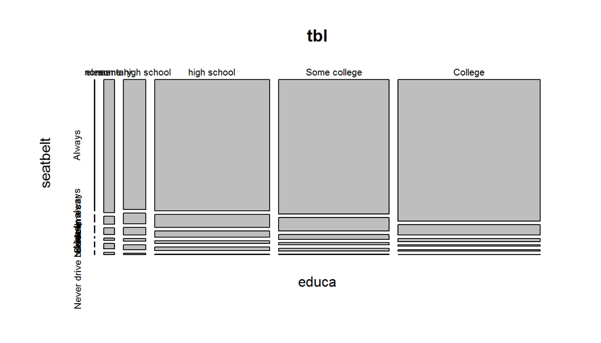

```r
brfss2013$educa <- plyr::mapvalues(brfss2013$educa,
                                   from=c("Never attended school or only kindergarten",
                                          "Grades 1 through 8 (Elementary)",
                                          "Grades 9 though 11 (Some high school)",
                                          "Grade 12 or GED (High school graduate)",
                                          "College 1 year to 3 years (Some college or technical school)",
                                          "College 4 years or more (College graduate)"),
                                   to=c('none',
                                        'elementary',
                                        'some high school',
                                        'high school',
                                        'Some college',
                                        'College'))

educ_seatbelt <- brfss2013 %>%
  select(educa, seatbelt) %>%
  filter(!is.na(educa) & !is.na(seatbelt)) %>%
  group_by(educa, seatbelt) %>%
  arrange(educa, seatbelt)

tbl <- table(educ_seatbelt)
mosaicplot(tbl)
```